# BFI Model Comparison: Llama-2 7B vs Llama-3.2 3B (with Neutral Baseline)

Ethan Brown

2026-03-30

## Overview

This analysis compares two models on the BFI personality instrument:

**Note**: Llama-3.2 results are preliminary — the inference run is still in progress. Incomplete SPIDs (missing items) are dropped; neutral preambles are partially available.

Key questions:

1. Does Llama-3.2 show more response variability (less ceiling effect, more use of categories 2/4)?
2. Does **soft-evidence IRT** work with a model that has more entropy in its logprob distributions?
3. Where does the model’s “resting state” (neutral, no-persona) fall on the trait scales defined by the persona-variation IRT fit?

## 1. Data Loading

```r
df_llama2 <- read_csv("results_bfi-full_llama2-7b-chat_0.csv", show_col_types = FALSE) %>%
  mutate(model = "Llama-2 7B",
         response = as.integer(logprob_argmax),
         is_neutral = FALSE)

df_llama3 <- read_csv("results_bfi-neutral_llama3.2-3b_0.csv", show_col_types = FALSE) %>%
  mutate(model = "Llama-3.2 3B",
         response = as.integer(logprob_argmax),
         is_neutral = item_preamble_id %>% str_starts("d0-"))

# Drop incomplete SPIDs (< 44 items) from partial run
spid_completeness <- df_llama3 %>% count(spid) %>% filter(n == 44)
n_dropped <- n_distinct(df_llama3$spid) - nrow(spid_completeness)
df_llama3 <- df_llama3 %>% semi_join(spid_completeness, by = "spid")
cat(sprintf("Llama-3.2: kept %d complete SPIDs, dropped %d incomplete\n",
            nrow(spid_completeness), n_dropped))
```

```
## Llama-3.2: kept 895 complete SPIDs, dropped 5 incomplete
```

```r
cat(sprintf("  Persona SPIDs: %d, Neutral SPIDs: %d\n",
            n_distinct(df_llama3 %>% filter(!is_neutral) %>% pull(spid)),
            n_distinct(df_llama3 %>% filter(is_neutral) %>% pull(spid))))
```

```
##   Persona SPIDs: 885, Neutral SPIDs: 10
```

```r
bfi_scales <- list(
  `BFI-EXT` = list(
    items = c("bf1","bf6","bf11","bf16","bf21","bf26","bf31","bf36"),
    reverse = c("bf6","bf21","bf31")
  ),
  `BFI-AGR` = list(
    items = c("bf2","bf7","bf12","bf17","bf22","bf27","bf32","bf37","bf42"),
    reverse = c("bf2","bf12","bf27","bf37")
  ),
  `BFI-CON` = list(
    items = c("bf3","bf8","bf13","bf18","bf23","bf28","bf33","bf38","bf43"),
    reverse = c("bf8","bf18","bf23","bf43")
  ),
  `BFI-NEU` = list(
    items = c("bf4","bf9","bf14","bf19","bf24","bf29","bf34","bf39"),
    reverse = c("bf9","bf24","bf34")
  ),
  `BFI-OPE` = list(
    items = c("bf5","bf10","bf15","bf20","bf25","bf30","bf35","bf40","bf41","bf44"),
    reverse = c("bf35","bf41")
  )
)
```

## 2. Response Distribution Comparison

### Category usage

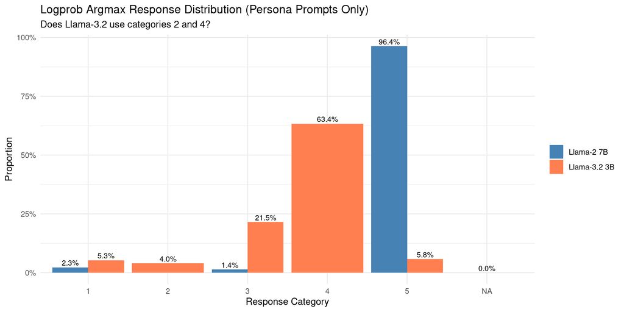

```r
bind_rows(
  df_llama2 %>% filter(!is_neutral) %>% select(model, response),
  df_llama3 %>% filter(!is_neutral) %>% select(model, response)
) %>%
  count(model, response) %>%
  group_by(model) %>%
  mutate(pct = n / sum(n)) %>%
  ungroup() %>%
  ggplot(aes(x = factor(response), y = pct, fill = model)) +
  geom_col(position = "dodge") +
  geom_text(aes(label = sprintf("%.1f%%", pct * 100)),
            position = position_dodge(width = 0.9), vjust = -0.3, size = 3) +
  scale_y_continuous(labels = scales::percent) +
  scale_fill_manual(values = c("Llama-2 7B" = "steelblue", "Llama-3.2 3B" = "coral")) +
  labs(title = "Logprob Argmax Response Distribution (Persona Prompts Only)",
       subtitle = "Does Llama-3.2 use categories 2 and 4?",
       x = "Response Category", y = "Proportion", fill = NULL) +
  theme_minimal()
```

### Neutral vs persona within Llama-3.2

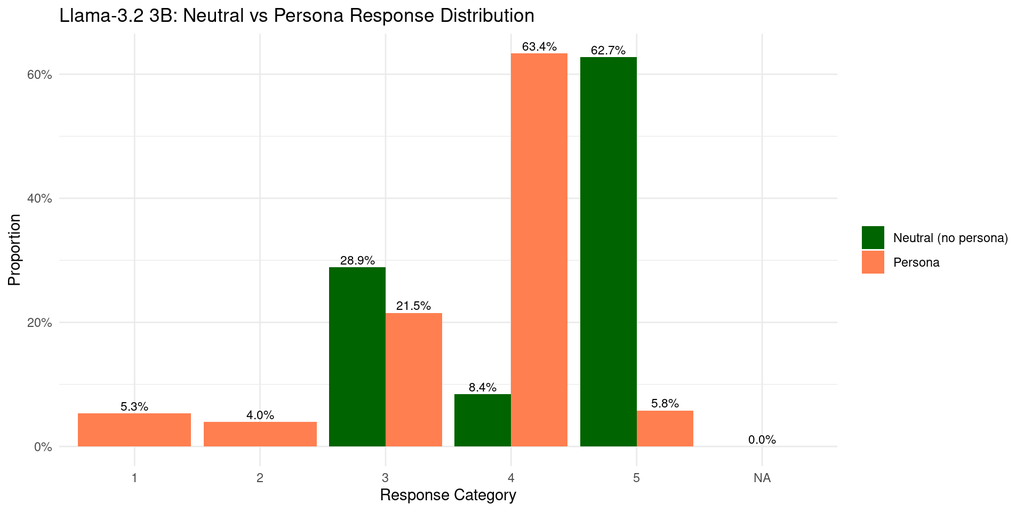

```r
df_llama3 %>%
  mutate(condition = ifelse(is_neutral, "Neutral (no persona)", "Persona")) %>%
  count(condition, response) %>%
  group_by(condition) %>%
  mutate(pct = n / sum(n)) %>%
  ungroup() %>%
  ggplot(aes(x = factor(response), y = pct, fill = condition)) +
  geom_col(position = "dodge") +
  geom_text(aes(label = sprintf("%.1f%%", pct * 100)),
            position = position_dodge(width = 0.9), vjust = -0.3, size = 3) +
  scale_y_continuous(labels = scales::percent) +
  scale_fill_manual(values = c("Neutral (no persona)" = "darkgreen",
                                "Persona" = "coral")) +
  labs(title = "Llama-3.2 3B: Neutral vs Persona Response Distribution",
       x = "Response Category", y = "Proportion", fill = NULL) +
  theme_minimal()
```

### Mean logprob distribution shape

The colleague found Llama-3.2 has near-uniform entropy (~1.4/1.61). Let’s check whether this holds with the BFI framing and persona prompts.

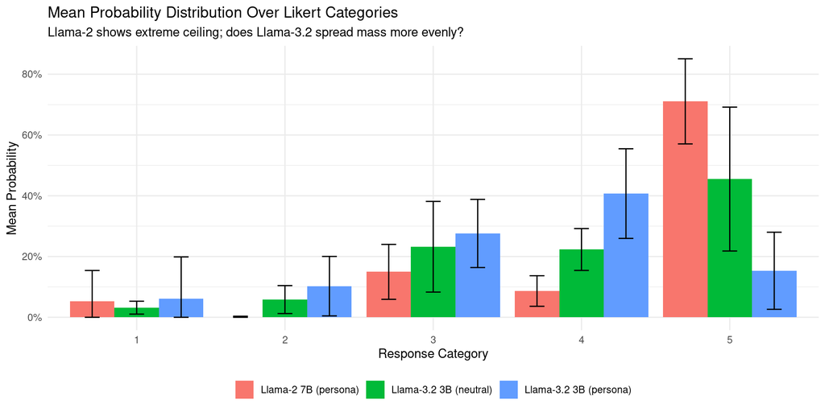

```r
compute_mean_probs <- function(df, label) {
  lp_cols <- df %>% select(logprob_1:logprob_5) %>% as.matrix()
  lp_floor <- min(lp_cols, na.rm = TRUE)
  lp_cols[is.na(lp_cols)] <- lp_floor
  probs <- exp(lp_cols)
  probs <- probs / rowSums(probs)
  tibble(
    category = 1:5,
    mean_prob = colMeans(probs),
    sd_prob = apply(probs, 2, sd),
    label = label
  )
}

bind_rows(
  compute_mean_probs(df_llama2, "Llama-2 7B (persona)"),
  compute_mean_probs(df_llama3 %>% filter(!is_neutral), "Llama-3.2 3B (persona)"),
  compute_mean_probs(df_llama3 %>% filter(is_neutral), "Llama-3.2 3B (neutral)")
) %>%
  ggplot(aes(x = factor(category), y = mean_prob, fill = label)) +
  geom_col(position = "dodge") +
  geom_errorbar(aes(ymin = pmax(mean_prob - sd_prob, 0),
                    ymax = pmin(mean_prob + sd_prob, 1)),
                position = position_dodge(width = 0.9), width = 0.3) +
  scale_y_continuous(labels = scales::percent) +
  labs(title = "Mean Probability Distribution Over Likert Categories",
       subtitle = "Llama-2 shows extreme ceiling; does Llama-3.2 spread mass more evenly?",
       x = "Response Category", y = "Mean Probability", fill = NULL) +
  theme_minimal() +
  theme(legend.position = "bottom")
```

### Per-item entropy comparison

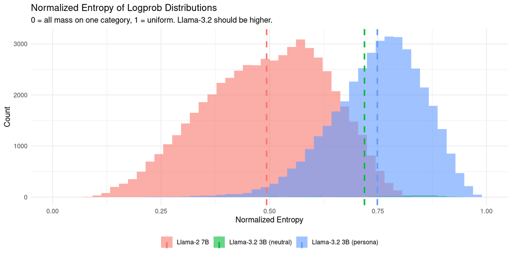

```r
item_entropy <- function(df, label) {
  lp_cols <- df %>% select(logprob_1:logprob_5) %>% as.matrix()
  lp_floor <- min(lp_cols, na.rm = TRUE)
  lp_cols[is.na(lp_cols)] <- lp_floor
  probs <- exp(lp_cols)
  probs <- probs / rowSums(probs)
  # Shannon entropy per row
  H <- -rowSums(probs * log(probs + 1e-30))
  tibble(entropy = H, normed_entropy = H / log(5), label = label)
}

entropy_df <- bind_rows(
  item_entropy(df_llama2, "Llama-2 7B"),
  item_entropy(df_llama3 %>% filter(!is_neutral), "Llama-3.2 3B (persona)"),
  item_entropy(df_llama3 %>% filter(is_neutral), "Llama-3.2 3B (neutral)")
)

entropy_df %>%
  ggplot(aes(x = normed_entropy, fill = label)) +
  geom_histogram(bins = 50, alpha = 0.6, position = "identity") +
  geom_vline(data = entropy_df %>% group_by(label) %>%
               summarise(mean_H = mean(normed_entropy)),
             aes(xintercept = mean_H, color = label), linetype = "dashed", linewidth = 1) +
  scale_x_continuous(limits = c(0, 1)) +
  labs(title = "Normalized Entropy of Logprob Distributions",
       subtitle = "0 = all mass on one category, 1 = uniform. Llama-3.2 should be higher.",
       x = "Normalized Entropy", y = "Count", fill = NULL, color = NULL) +
  theme_minimal() +
  theme(legend.position = "bottom")
```

```r
entropy_df %>%
  group_by(label) %>%
  summarise(
    mean_entropy = mean(normed_entropy),
    sd_entropy = sd(normed_entropy),
    median_entropy = median(normed_entropy)
  ) %>%
  knitr::kable(digits = 3, caption = "Entropy summary statistics")
```

Entropy summary statistics

| label | mean_entropy | sd_entropy | median_entropy |
| --- | --- | --- | --- |
| Llama-2 7B | 0.493 | 0.140 | 0.503 |
| Llama-3.2 3B (neutral) | 0.719 | 0.162 | 0.778 |
| Llama-3.2 3B (persona) | 0.748 | 0.105 | 0.759 |

### Valid probability mass

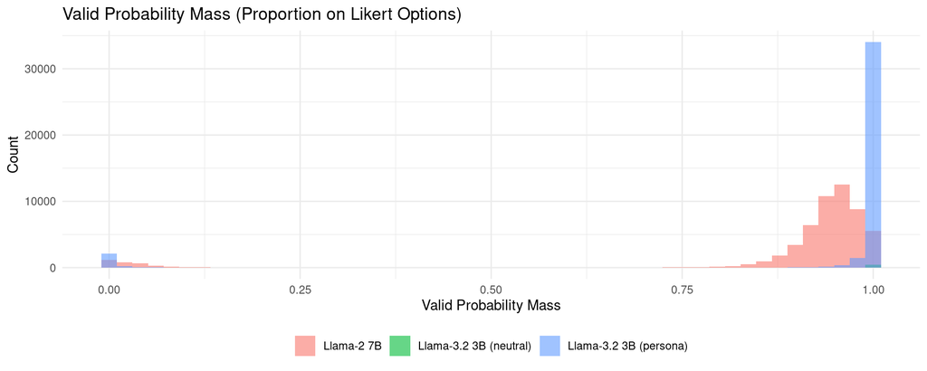

```r
bind_rows(
  df_llama2 %>% mutate(label = "Llama-2 7B") %>% select(label, valid_prob_mass),
  df_llama3 %>% filter(!is_neutral) %>%
    mutate(label = "Llama-3.2 3B (persona)") %>% select(label, valid_prob_mass),
  df_llama3 %>% filter(is_neutral) %>%
    mutate(label = "Llama-3.2 3B (neutral)") %>% select(label, valid_prob_mass)
) %>%
  ggplot(aes(x = valid_prob_mass, fill = label)) +
  geom_histogram(bins = 50, alpha = 0.6, position = "identity") +
  labs(title = "Valid Probability Mass (Proportion on Likert Options)",
       x = "Valid Probability Mass", y = "Count", fill = NULL) +
  theme_minimal() +
  theme(legend.position = "bottom")
```

## 3. IRT Model Fitting: Llama-3.2 (Persona Data)

We fit the same 4 models per trait as the Llama-2 analysis, using only the persona (non-neutral) data from Llama-3.2. The neutral data is held out for trait-placement later.

```r
df_l3_persona <- df_llama3 %>% filter(!is_neutral)
df_l3_neutral <- df_llama3 %>% filter(is_neutral)

# Person-by-item matrix for persona data
resp_wide_l3 <- df_l3_persona %>%
  select(spid, item_id, response) %>%
  pivot_wider(names_from = item_id, values_from = response) %>%
  arrange(spid)

spid_ids_l3 <- resp_wide_l3$spid
N_l3 <- nrow(resp_wide_l3)
all_items <- sort(unique(df_l3_persona$item_id))
J <- length(all_items)
K_raw <- 5L

cat(sprintf("Llama-3.2 persona data: %d SPIDs x %d items\n", N_l3, J))
```

```
## Llama-3.2 persona data: 885 SPIDs x 44 items
```

```r
cat(sprintf("Response categories observed: %s\n",
            paste(sort(unique(df_l3_persona$response)), collapse = ", ")))
```

```
## Response categories observed: 1, 2, 3, 4, 5
```

### Soft-evidence array (Llama-3.2)

With Llama-3.2’s higher entropy, we may be able to keep all 5 categories rather than collapsing to 3. We construct both versions.

```r
lp_l3 <- df_l3_persona %>%
  select(spid, item_id, logprob_1, logprob_2, logprob_3, logprob_4, logprob_5) %>%
  arrange(spid, item_id)

lp_mat_l3 <- lp_l3 %>% select(starts_with("logprob_")) %>% as.matrix()
lp_floor_l3 <- min(lp_mat_l3, na.rm = TRUE)
n_na_l3 <- sum(is.na(lp_mat_l3))
lp_mat_l3[is.na(lp_mat_l3)] <- lp_floor_l3

prob_mat_l3 <- exp(lp_mat_l3)
prob_mat_l3 <- prob_mat_l3 / rowSums(prob_mat_l3)

# Full 5-category array: N x J x 5
pi_array_5_l3 <- array(prob_mat_l3, dim = c(J, N_l3, K_raw))
pi_array_5_l3 <- aperm(pi_array_5_l3, c(2, 1, 3))

# Also compute 3-category collapse for direct comparison with Llama-2
pi_array_3_l3 <- array(0, dim = c(N_l3, J, 3L))
pi_array_3_l3[, , 1] <- pi_array_5_l3[, , 1] + pi_array_5_l3[, , 2]
pi_array_3_l3[, , 2] <- pi_array_5_l3[, , 3]
pi_array_3_l3[, , 3] <- pi_array_5_l3[, , 4] + pi_array_5_l3[, , 5]

cat(sprintf("5-category mean probs: %s\n",
            paste(sprintf("%.3f", colMeans(matrix(prob_mat_l3, ncol = 5))), collapse = ", ")))
```

```
## 5-category mean probs: 0.061, 0.102, 0.276, 0.407, 0.153
```

```r
cat(sprintf("3-category mean probs: low=%.3f, mid=%.3f, high=%.3f\n",
            mean(pi_array_3_l3[,,1]), mean(pi_array_3_l3[,,2]), mean(pi_array_3_l3[,,3])))
```

```
## 3-category mean probs: low=0.164, mid=0.276, high=0.560
```

```r
cat(sprintf("Imputed %d NA logprobs with floor %.2f\n", n_na_l3, lp_floor_l3))
```

```
## Imputed 1836 NA logprobs with floor -16.39
```

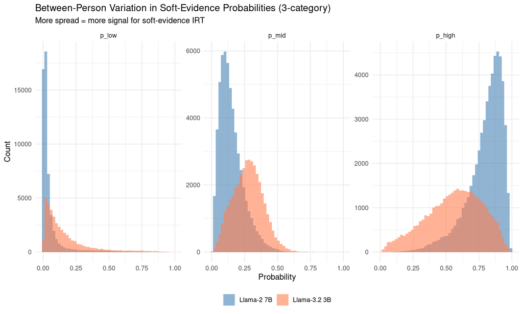

```r
# Between-person variation in soft evidence — the key diagnostic
# If this shows more spread than Llama-2, soft IRT should work better
cat_var_l3 <- tibble(
  p_low = as.vector(pi_array_3_l3[,,1]),
  p_mid = as.vector(pi_array_3_l3[,,2]),
  p_high = as.vector(pi_array_3_l3[,,3])
) %>%
  pivot_longer(everything(), names_to = "category", values_to = "probability") %>%
  mutate(category = fct_relevel(category, "p_low", "p_mid", "p_high"),
         model = "Llama-3.2 3B")

# Load Llama-2 soft evidence for comparison
lp_l2 <- df_llama2 %>%
  select(spid, item_id, logprob_1:logprob_5) %>%
  arrange(spid, item_id)
lp_mat_l2 <- lp_l2 %>% select(starts_with("logprob_")) %>% as.matrix()
lp_floor_l2 <- min(lp_mat_l2, na.rm = TRUE)
lp_mat_l2[is.na(lp_mat_l2)] <- lp_floor_l2
prob_mat_l2 <- exp(lp_mat_l2)
prob_mat_l2 <- prob_mat_l2 / rowSums(prob_mat_l2)

N_l2 <- nrow(df_llama2 %>% distinct(spid))
pi_array_3_l2 <- array(0, dim = c(N_l2, J, 3L))
pi5_l2 <- array(prob_mat_l2, dim = c(J, N_l2, K_raw))
pi5_l2 <- aperm(pi5_l2, c(2, 1, 3))
pi_array_3_l2[, , 1] <- pi5_l2[, , 1] + pi5_l2[, , 2]
pi_array_3_l2[, , 2] <- pi5_l2[, , 3]
pi_array_3_l2[, , 3] <- pi5_l2[, , 4] + pi5_l2[, , 5]

cat_var_l2 <- tibble(
  p_low = as.vector(pi_array_3_l2[,,1]),
  p_mid = as.vector(pi_array_3_l2[,,2]),
  p_high = as.vector(pi_array_3_l2[,,3])
) %>%
  pivot_longer(everything(), names_to = "category", values_to = "probability") %>%
  mutate(category = fct_relevel(category, "p_low", "p_mid", "p_high"),
         model = "Llama-2 7B")

bind_rows(cat_var_l2, cat_var_l3) %>%
  ggplot(aes(x = probability, fill = model)) +
  geom_histogram(bins = 50, alpha = 0.6, position = "identity") +
  facet_wrap(~category, scales = "free_y") +
  scale_fill_manual(values = c("Llama-2 7B" = "steelblue", "Llama-3.2 3B" = "coral")) +
  labs(title = "Between-Person Variation in Soft-Evidence Probabilities (3-category)",
       subtitle = "More spread = more signal for soft-evidence IRT",
       x = "Probability", y = "Count", fill = NULL) +
  theme_minimal() +
  theme(legend.position = "bottom")
```

### Helper functions

```r
build_softmat_from_model <- function(mod, pi_sub, items) {
  K_vec <- extract.mirt(mod, "K")
  itemloc <- extract.mirt(mod, "itemloc")
  ncols <- sum(K_vec)
  J_sub <- length(items)
  N_local <- dim(pi_sub)[1]
  K_avail <- dim(pi_sub)[3]
  softmat <- matrix(0, nrow = N_local, ncol = ncols)

  for (jj in 1:J_sub) {
    cols <- itemloc[jj]:(itemloc[jj + 1] - 1)
    Kj <- K_vec[jj]
    if (Kj == K_avail) {
      softmat[, cols] <- pi_sub[, jj, ]
    } else if (Kj < K_avail) {
      # Collapse categories to match observed K
      # Map K_avail categories into Kj bins
      # For K_avail=5, Kj=3: low=(1+2), mid=(3), high=(4+5)
      # For K_avail=5, Kj=2: low=(1+2+3), high=(4+5)
      if (K_avail == 5 && Kj == 3) {
        softmat[, cols[1]] <- pi_sub[, jj, 1] + pi_sub[, jj, 2]
        softmat[, cols[2]] <- pi_sub[, jj, 3]
        softmat[, cols[3]] <- pi_sub[, jj, 4] + pi_sub[, jj, 5]
      } else if (K_avail == 5 && Kj == 2) {
        softmat[, cols[1]] <- pi_sub[, jj, 1] + pi_sub[, jj, 2] + pi_sub[, jj, 3]
        softmat[, cols[2]] <- pi_sub[, jj, 4] + pi_sub[, jj, 5]
      } else if (K_avail == 3 && Kj == 2) {
        softmat[, cols[1]] <- pi_sub[, jj, 1] + pi_sub[, jj, 2]
        softmat[, cols[2]] <- pi_sub[, jj, 3]
      } else {
        # Generic fallback: spread evenly
        warning(sprintf("Unhandled K collapse: K_avail=%d -> Kj=%d for item %d", K_avail, Kj, jj))
        softmat[, cols] <- pi_sub[, jj, 1:Kj]
      }
    }
  }
  softmat
}

# Build soft-evidence array for neutral data from the same logprob structure
build_neutral_softmat <- function(df_neutral, items, item_order, mod, reverse_items) {
  K_vec <- extract.mirt(mod, "K")
  itemloc <- extract.mirt(mod, "itemloc")
  ncols <- sum(K_vec)
  K_avail <- max(K_vec)

  # There are multiple neutral SPIDs (5 framings x 5 postambles = 25 per item)
  # We score each separately, then can average or report all
  neutral_spids <- sort(unique(df_neutral$spid))
  N_neut <- length(neutral_spids)

  softmat_list <- list()
  dat_list <- list()

  for (s in neutral_spids) {
    s_data <- df_neutral %>%
      filter(spid == s) %>%
      arrange(item_id)

    # Build logprob matrix for this SPID's items
    lp <- s_data %>%
      select(item_id, logprob_1:logprob_5)

    # Reorder to match items
    lp <- lp %>% filter(item_id %in% items) %>%
      mutate(item_id = factor(item_id, levels = items)) %>%
      arrange(item_id)

    if (nrow(lp) != length(items)) next

    lp_vals <- lp %>% select(logprob_1:logprob_5) %>% as.matrix()
    lp_floor <- min(lp_vals, na.rm = TRUE)
    lp_vals[is.na(lp_vals)] <- lp_floor
    probs <- exp(lp_vals)
    probs <- probs / rowSums(probs)

    # Reverse-key
    for (ri in reverse_items) {
      ri_idx <- which(items == ri)
      probs[ri_idx, ] <- probs[ri_idx, 5:1]
    }

    # Build response vector (top-1)
    resp <- as.integer(lp$item_id %>% {
      s_data %>% filter(item_id %in% items) %>%
        mutate(item_id = factor(item_id, levels = items)) %>%
        arrange(item_id) %>% pull(logprob_argmax) %>% as.integer()
    })
    for (ri in reverse_items) {
      ri_idx <- which(items == ri)
      resp[ri_idx] <- 6L - resp[ri_idx]
    }

    # Build 1-row softmat
    softmat_row <- matrix(0, nrow = 1, ncol = ncols)
    J_sub <- length(items)
    for (jj in 1:J_sub) {
      cols <- itemloc[jj]:(itemloc[jj + 1] - 1)
      Kj <- K_vec[jj]
      if (Kj == 5) {
        softmat_row[1, cols] <- probs[jj, ]
      } else if (Kj == 3) {
        softmat_row[1, cols[1]] <- probs[jj, 1] + probs[jj, 2]
        softmat_row[1, cols[2]] <- probs[jj, 3]
        softmat_row[1, cols[3]] <- probs[jj, 4] + probs[jj, 5]
      } else if (Kj == 2) {
        softmat_row[1, cols[1]] <- probs[jj, 1] + probs[jj, 2] + probs[jj, 3]
        softmat_row[1, cols[2]] <- probs[jj, 4] + probs[jj, 5]
      }
    }
    softmat_list[[s]] <- softmat_row
    dat_list[[s]] <- resp
  }

  list(
    softmat = do.call(rbind, softmat_list),
    dat = do.call(rbind, dat_list) %>% as.data.frame() %>% setNames(items),
    spids = names(softmat_list)
  )
}
```

### Model fitting loop

```r
results_l3 <- list()

# Determine which soft-evidence array to use based on observed categories
# If Llama-3.2 uses all 5 categories, we can keep the full array
obs_cats_l3 <- sort(unique(df_l3_persona$response))
use_5cat <- length(obs_cats_l3) == 5
cat(sprintf("Observed categories: %s → using %d-category soft evidence\n",
            paste(obs_cats_l3, collapse = ","), ifelse(use_5cat, 5, 3)))

for (scale_id in names(bfi_scales)) {
  items <- bfi_scales[[scale_id]]$items
  rev_items <- bfi_scales[[scale_id]]$reverse
  J_sub <- length(items)
  item_idx <- match(items, all_items)

  # Top-1 response matrix
  dat_top1 <- resp_wide_l3 %>% select(all_of(items)) %>% as.data.frame()
  for (ri in rev_items) dat_top1[[ri]] <- 6L - dat_top1[[ri]]

  # Soft-evidence sub-array (reverse-keyed) — use 5-cat if all observed
  if (use_5cat) {
    pi_sub <- pi_array_5_l3[, item_idx, , drop = FALSE]
  } else {
    pi_sub <- pi_array_3_l3[, item_idx, , drop = FALSE]
  }
  for (ri in rev_items) {
    ri_idx <- which(items == ri)
    K_sub <- dim(pi_sub)[3]
    pi_sub[, ri_idx, ] <- pi_sub[, ri_idx, K_sub:1]
  }

  cat(sprintf("\n=== %s (%d items) ===\n", scale_id, J_sub))

  # 1. GRM top-1
  mod_grm_top1 <- tryCatch(
    mirt(dat_top1, 1, itemtype = "graded", verbose = FALSE, TOL = 1e-4),
    error = function(e) { cat(sprintf("  GRM top-1 failed: %s\n", e$message)); NULL }
  )

  # Build softmat from GRM's K structure
  softmat_grm <- if (!is.null(mod_grm_top1)) {
    build_softmat_from_model(mod_grm_top1, pi_sub, items)
  }

  # 2. GRM soft
  mod_grm_soft <- if (!is.null(softmat_grm)) {
    tryCatch(
      mirt(dat_top1, 1, itemtype = "graded", verbose = FALSE, TOL = 1e-4,
           technical = list(softevidence = softmat_grm)),
      error = function(e) { cat(sprintf("  GRM soft failed: %s\n", e$message)); NULL }
    )
  }

  # 3. NRM top-1
  mod_nrm_top1 <- tryCatch(
    mirt(dat_top1, 1, itemtype = "nominal", verbose = FALSE, TOL = 1e-4),
    error = function(e) { cat(sprintf("  NRM top-1 failed: %s\n", e$message)); NULL }
  )

  # Build softmat for NRM
  softmat_nrm <- if (!is.null(mod_nrm_top1)) {
    build_softmat_from_model(mod_nrm_top1, pi_sub, items)
  }

  # 4. NRM soft
  mod_nrm_soft <- if (!is.null(softmat_nrm)) {
    tryCatch(
      mirt(dat_top1, 1, itemtype = "nominal", verbose = FALSE, TOL = 1e-4,
           technical = list(softevidence = softmat_nrm)),
      error = function(e) { cat(sprintf("  NRM soft failed: %s\n", e$message)); NULL }
    )
  }

  results_l3[[scale_id]] <- list(
    grm_top1 = mod_grm_top1, grm_soft = mod_grm_soft,
    nrm_top1 = mod_nrm_top1, nrm_soft = mod_nrm_soft,
    items = items, reverse = rev_items,
    dat_top1 = dat_top1, softmat_grm = softmat_grm, pi_sub = pi_sub
  )
}
```

[output not shown]

## 4. Results: Top-1 IRT Comparison

### Fit statistics

```r
# Load Llama-2 results
results_l2 <- readRDS("fit_irt_bfi_full_results.rds")

top1_both <- names(bfi_scales) %>%
  map_dfr(function(s) {
    r2 <- results_l2[[s]]
    r3 <- results_l3[[s]]
    tibble(
      Scale = s,
      # Llama-2
      L2_GRM_AIC = if (!is.null(r2$grm_top1)) r2$grm_top1@Fit$AIC else NA_real_,
      L2_NRM_AIC = if (!is.null(r2$nrm_top1)) r2$nrm_top1@Fit$AIC else NA_real_,
      L2_preferred = ifelse(L2_GRM_AIC < L2_NRM_AIC, "GRM", "NRM"),
      # Llama-3.2
      L3_GRM_AIC = if (!is.null(r3$grm_top1)) r3$grm_top1@Fit$AIC else NA_real_,
      L3_NRM_AIC = if (!is.null(r3$nrm_top1)) r3$nrm_top1@Fit$AIC else NA_real_,
      L3_preferred = ifelse(L3_GRM_AIC < L3_NRM_AIC, "GRM", "NRM")
    )
  })

top1_both %>%
  knitr::kable(digits = 1,
               caption = "Top-1 AIC: Llama-2 7B vs Llama-3.2 3B")
```

Top-1 AIC: Llama-2 7B vs Llama-3.2 3B

| Scale | L2_GRM_AIC | L2_NRM_AIC | L2_preferred | L3_GRM_AIC | L3_NRM_AIC | L3_preferred |
| --- | --- | --- | --- | --- | --- | --- |
| BFI-EXT | 2123.8 | 1886.5 | NRM | 11586.4 | 11679.5 | GRM |
| BFI-AGR | 2951.7 | 2938.2 | NRM | 12771.7 | 12317.0 | NRM |
| BFI-CON | 2092.2 | 2458.1 | GRM | 10401.1 | 10072.9 | NRM |
| BFI-NEU | 1637.0 | 1689.6 | GRM | 9332.1 | 8251.5 | NRM |
| BFI-OPE | 1764.4 | 1778.4 | GRM | 13489.0 | 15167.0 | GRM |

### GRM discrimination comparison

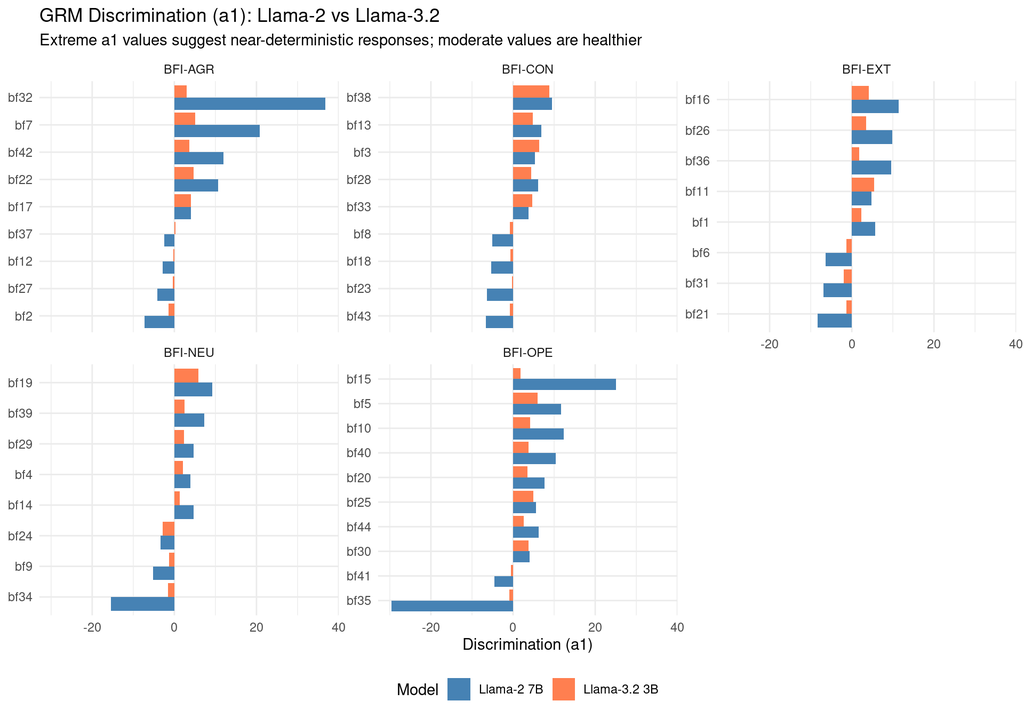

```r
get_grm_params <- function(results, model_label) {
  names(results) %>%
    map_dfr(function(s) {
      r <- results[[s]]
      if (is.null(r$grm_top1)) return(NULL)
      coefs <- coef(r$grm_top1, simplify = TRUE)$items
      as_tibble(coefs, rownames = "item") %>%
        mutate(Scale = s, Model = model_label, .before = 1)
    })
}

bind_rows(
  get_grm_params(results_l2, "Llama-2 7B"),
  get_grm_params(results_l3, "Llama-3.2 3B")
) %>%
  ggplot(aes(x = reorder(item, a1), y = a1, fill = Model)) +
  geom_col(position = "dodge") +
  coord_flip() +
  facet_wrap(~Scale, scales = "free_y") +
  scale_fill_manual(values = c("Llama-2 7B" = "steelblue", "Llama-3.2 3B" = "coral")) +
  labs(title = "GRM Discrimination (a1): Llama-2 vs Llama-3.2",
       subtitle = "Extreme a1 values suggest near-deterministic responses; moderate values are healthier",
       x = NULL, y = "Discrimination (a1)") +
  theme_minimal() +
  theme(legend.position = "bottom")
```

## 5. Soft-Evidence IRT: Does It Work for Llama-3.2?

This is the key question. Llama-2’s soft evidence collapsed (a1 → 0) because of homogeneous distributions. If Llama-3.2 has more entropy, the soft-evidence approach should recover meaningful discrimination.

```r
soft_both <- names(bfi_scales) %>%
  map_dfr(function(s) {
    r2 <- results_l2[[s]]
    r3 <- results_l3[[s]]

    # Llama-2 soft GRM a1 range
    l2_soft_a1 <- if (!is.null(r2$grm_soft)) {
      range(coef(r2$grm_soft, simplify = TRUE)$items[, "a1"])
    } else c(NA, NA)

    # Llama-3.2 soft GRM a1 range
    l3_soft_a1 <- if (!is.null(r3$grm_soft)) {
      range(coef(r3$grm_soft, simplify = TRUE)$items[, "a1"])
    } else c(NA, NA)

    tibble(
      Scale = s,
      L2_soft_a1_range = sprintf("[%.2f, %.2f]", l2_soft_a1[1], l2_soft_a1[2]),
      L3_soft_a1_range = sprintf("[%.2f, %.2f]", l3_soft_a1[1], l3_soft_a1[2]),
      L2_degenerate = all(abs(l2_soft_a1) < 0.1),
      L3_degenerate = all(abs(l3_soft_a1) < 0.1)
    )
  })

soft_both %>%
  knitr::kable(caption = "Soft-evidence GRM discrimination ranges: does a1 stay alive?")
```

Soft-evidence GRM discrimination ranges: does a1 stay alive?

| Scale | L2_soft_a1_range | L3_soft_a1_range | L2_degenerate | L3_degenerate |
| --- | --- | --- | --- | --- |
| BFI-EXT | [-0.00, 0.00] | [-0.00, 0.00] | TRUE | TRUE |
| BFI-AGR | [-0.00, 0.00] | [-0.00, 0.00] | TRUE | TRUE |
| BFI-CON | [-0.00, 0.00] | [-0.00, 0.00] | TRUE | TRUE |
| BFI-NEU | [-0.00, 0.00] | [-0.00, 0.00] | TRUE | TRUE |
| BFI-OPE | [-0.00, 0.00] | [-0.19, 0.52] | TRUE | FALSE |

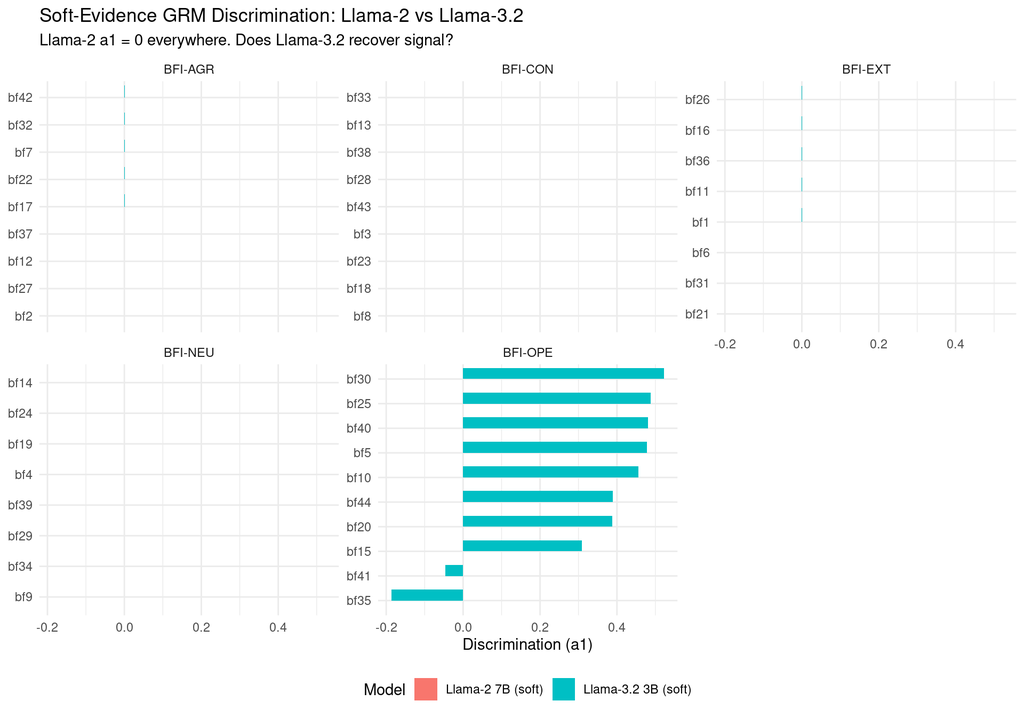

```r
get_soft_params <- function(results, model_label) {
  names(results) %>%
    map_dfr(function(s) {
      r <- results[[s]]
      if (is.null(r$grm_soft)) return(NULL)
      coefs <- coef(r$grm_soft, simplify = TRUE)$items
      as_tibble(coefs, rownames = "item") %>%
        mutate(Scale = s, Model = model_label, .before = 1)
    })
}

soft_params_both <- bind_rows(
  get_soft_params(results_l2, "Llama-2 7B (soft)"),
  get_soft_params(results_l3, "Llama-3.2 3B (soft)")
)

if (nrow(soft_params_both) > 0) {
  soft_params_both %>%
    ggplot(aes(x = reorder(item, a1), y = a1, fill = Model)) +
    geom_col(position = "dodge") +
    coord_flip() +
    facet_wrap(~Scale, scales = "free_y") +
    labs(title = "Soft-Evidence GRM Discrimination: Llama-2 vs Llama-3.2",
         subtitle = "Llama-2 a1 = 0 everywhere. Does Llama-3.2 recover signal?",
         x = NULL, y = "Discrimination (a1)") +
    theme_minimal() +
    theme(legend.position = "bottom")
}
```

### Top-1 vs soft-evidence correlation (Llama-3.2)

```r
top_soft_cor_l3 <- names(results_l3) %>%
  map_dfr(function(s) {
    r <- results_l3[[s]]
    if (is.null(r$grm_top1) || is.null(r$grm_soft)) return(NULL)
    a1_top <- coef(r$grm_top1, simplify = TRUE)$items[, "a1"]
    a1_soft <- coef(r$grm_soft, simplify = TRUE)$items[, "a1"]
    tibble(
      Scale = s,
      cor_a1 = cor(a1_top, a1_soft),
      mean_abs_diff = mean(abs(a1_top - a1_soft))
    )
  })

top_soft_cor_l3 %>%
  knitr::kable(digits = 3,
               caption = "Llama-3.2: correlation between top-1 and soft-evidence a1 parameters")
```

Llama-3.2: correlation between top-1 and soft-evidence a1 parameters

| Scale | cor_a1 | mean_abs_diff |
| --- | --- | --- |
| BFI-EXT | 0.953 | 2.723 |
| BFI-AGR | 0.932 | 2.532 |
| BFI-CON | 0.826 | 3.515 |
| BFI-NEU | 0.167 | 2.474 |
| BFI-OPE | 0.926 | 2.825 |

## 6. Expected Value IRT: Using Logprobs as Continuous Scores

Soft-evidence IRT collapses because the *distributional shape* is an item property, not a person property — personas shift the mode but not the shape. An alternative: compute the **expected value** E[X] = Σ_k k·π_k as a continuous item score. This captures the gradual probability shift across personas (e.g., P(“5”) rising from 0.55 to 0.75 before it becomes the argmax) and provides finer between-person resolution than the discrete top-1 response.

### Computing expected values

```r
# Compute EV for each person x item from logprob distributions
compute_ev <- function(df) {
  lp_cols <- df %>% select(logprob_1:logprob_5) %>% as.matrix()
  lp_floor <- min(lp_cols, na.rm = TRUE)
  lp_cols[is.na(lp_cols)] <- lp_floor
  probs <- exp(lp_cols)
  probs <- probs / rowSums(probs)
  rowSums(probs * matrix(1:5, nrow = nrow(probs), ncol = 5, byrow = TRUE))
}

df_l3_persona <- df_l3_persona %>%
  mutate(ev_response = compute_ev(df_l3_persona))
df_l3_neutral <- df_l3_neutral %>%
  mutate(ev_response = compute_ev(df_l3_neutral))

# Also compute for Llama-2
df_llama2 <- df_llama2 %>%
  mutate(ev_response = compute_ev(df_llama2))
```

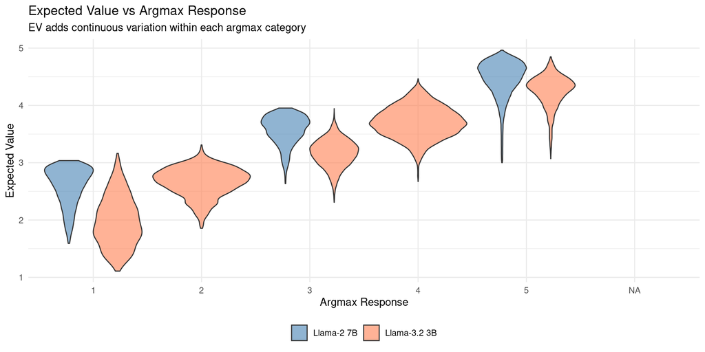

```r
# EV vs argmax comparison
bind_rows(
  df_llama2 %>% select(model, response, ev_response),
  df_l3_persona %>% mutate(model = "Llama-3.2 3B") %>% select(model, response, ev_response)
) %>%
  ggplot(aes(x = factor(response), y = ev_response, fill = model)) +
  geom_violin(alpha = 0.6, scale = "width") +
  scale_fill_manual(values = c("Llama-2 7B" = "steelblue", "Llama-3.2 3B" = "coral")) +
  labs(title = "Expected Value vs Argmax Response",
       subtitle = "EV adds continuous variation within each argmax category",
       x = "Argmax Response", y = "Expected Value", fill = NULL) +
  theme_minimal() +
  theme(legend.position = "bottom")
```

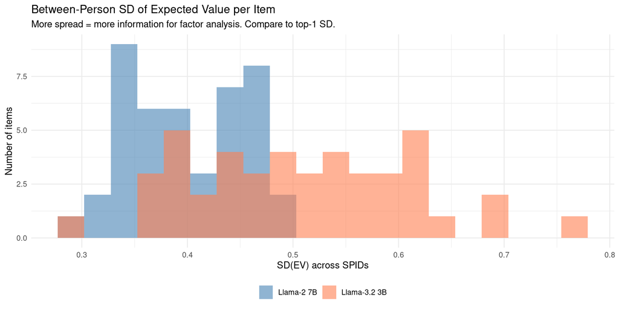

```r
# The key diagnostic: how much between-person EV variation exists per item?
ev_var <- bind_rows(
  df_llama2 %>%
    group_by(item_id) %>%
    summarise(ev_sd = sd(ev_response), ev_mean = mean(ev_response)) %>%
    mutate(model = "Llama-2 7B"),
  df_l3_persona %>%
    group_by(item_id) %>%
    summarise(ev_sd = sd(ev_response), ev_mean = mean(ev_response)) %>%
    mutate(model = "Llama-3.2 3B")
)

ev_var %>%
  ggplot(aes(x = ev_sd, fill = model)) +
  geom_histogram(bins = 20, alpha = 0.6, position = "identity") +
  scale_fill_manual(values = c("Llama-2 7B" = "steelblue", "Llama-3.2 3B" = "coral")) +
  labs(title = "Between-Person SD of Expected Value per Item",
       subtitle = "More spread = more information for factor analysis. Compare to top-1 SD.",
       x = "SD(EV) across SPIDs", y = "Number of items", fill = NULL) +
  theme_minimal() +
  theme(legend.position = "bottom")
```

### EV-based person-by-item matrix

```r
# Build EV response matrices (continuous)
ev_wide_l3 <- df_l3_persona %>%
  select(spid, item_id, ev_response) %>%
  pivot_wider(names_from = item_id, values_from = ev_response) %>%
  arrange(spid)

ev_wide_l2 <- df_llama2 %>%
  select(spid, item_id, ev_response) %>%
  pivot_wider(names_from = item_id, values_from = ev_response) %>%
  arrange(spid)
```

### Factor analysis on EV scores

```r
# Per-trait factor analysis on EV scores
ev_results <- list()

for (scale_id in names(bfi_scales)) {
  items <- bfi_scales[[scale_id]]$items
  rev_items <- bfi_scales[[scale_id]]$reverse

  # Llama-3.2 EV matrix
  ev_l3 <- ev_wide_l3 %>% select(all_of(items)) %>% as.data.frame()
  for (ri in rev_items) ev_l3[[ri]] <- 6 - ev_l3[[ri]]

  # Llama-2 EV matrix
  ev_l2 <- ev_wide_l2 %>% select(all_of(items)) %>% as.data.frame()
  for (ri in rev_items) ev_l2[[ri]] <- 6 - ev_l2[[ri]]

  # Single-factor extraction via principal axis
  fa_l3 <- tryCatch({
    pc <- prcomp(ev_l3, scale. = TRUE)
    loadings <- cor(ev_l3, pc$x[, 1])
    scores <- pc$x[, 1]
    var_explained <- pc$sdev[1]^2 / sum(pc$sdev^2)
    list(loadings = loadings[,1], scores = scores, var_explained = var_explained)
  }, error = function(e) NULL)

  fa_l2 <- tryCatch({
    pc <- prcomp(ev_l2, scale. = TRUE)
    loadings <- cor(ev_l2, pc$x[, 1])
    scores <- pc$x[, 1]
    var_explained <- pc$sdev[1]^2 / sum(pc$sdev^2)
    list(loadings = loadings[,1], scores = scores, var_explained = var_explained)
  }, error = function(e) NULL)

  # Neutral EV scores — filter for SPIDs that have all items in this scale
  ev_neutral <- df_l3_neutral %>%
    filter(item_id %in% items) %>%
    group_by(spid) %>%
    filter(n() == length(items)) %>%
    ungroup() %>%
    select(spid, item_id, ev_response) %>%
    pivot_wider(names_from = item_id, values_from = ev_response)

  neutral_scores <- NULL
  if (!is.null(fa_l3) && nrow(ev_neutral) > 0) {
    ev_neut_mat <- ev_neutral %>% select(all_of(items)) %>% as.data.frame()
    for (ri in rev_items) ev_neut_mat[[ri]] <- 6 - ev_neut_mat[[ri]]
    # Project onto the persona PC1 using predict
    pc_l3 <- prcomp(ev_l3, scale. = TRUE)
    neutral_scores <- predict(pc_l3, newdata = ev_neut_mat)[, 1]
  }

  ev_results[[scale_id]] <- list(
    fa_l3 = fa_l3, fa_l2 = fa_l2,
    neutral_scores = neutral_scores,
    neutral_spids = if (nrow(ev_neutral) > 0) ev_neutral$spid else character(0)
  )
}
```

### EV factor loadings comparison

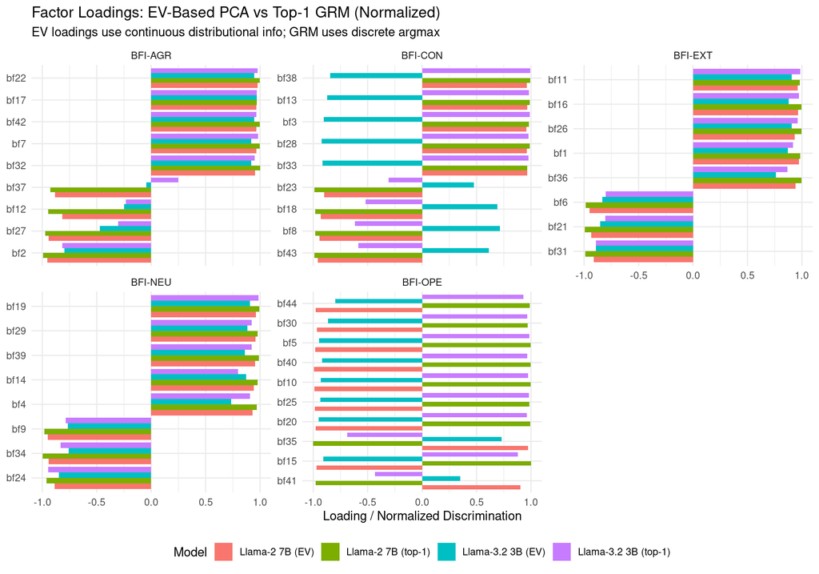

```r
loading_df <- names(ev_results) %>%
  map_dfr(function(s) {
    r <- ev_results[[s]]
    items <- bfi_scales[[s]]$items
    bind_rows(
      if (!is.null(r$fa_l2)) tibble(Scale = s, item = items,
        loading = r$fa_l2$loadings, Model = "Llama-2 7B (EV)"),
      if (!is.null(r$fa_l3)) tibble(Scale = s, item = items,
        loading = r$fa_l3$loadings, Model = "Llama-3.2 3B (EV)")
    )
  })

# Add top-1 GRM discrimination for comparison (normalized to loading scale)
grm_loading_df <- bind_rows(
  get_grm_params(results_l2, "Llama-2 7B (top-1)"),
  get_grm_params(results_l3, "Llama-3.2 3B (top-1)")
) %>%
  select(Scale, item, a1, Model) %>%
  # Normalize a1 to approx loading scale: loading ≈ a1 / sqrt(1 + a1^2)
  mutate(loading = a1 / sqrt(1 + a1^2))

all_loadings <- bind_rows(loading_df, grm_loading_df)

all_loadings %>%
  ggplot(aes(x = reorder(item, loading), y = loading, fill = Model)) +
  geom_col(position = "dodge") +
  coord_flip() +
  facet_wrap(~Scale, scales = "free_y") +
  labs(title = "Factor Loadings: EV-Based PCA vs Top-1 GRM (Normalized)",
       subtitle = "EV loadings use continuous distributional info; GRM uses discrete argmax",
       x = NULL, y = "Loading / Normalized Discrimination") +
  theme_minimal() +
  theme(legend.position = "bottom")
```

### Variance explained

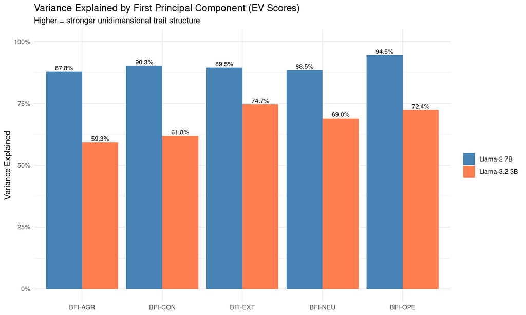

```r
var_df <- names(ev_results) %>%
  map_dfr(function(s) {
    r <- ev_results[[s]]
    bind_rows(
      if (!is.null(r$fa_l2)) tibble(Scale = s, Model = "Llama-2 7B",
        var_explained = r$fa_l2$var_explained),
      if (!is.null(r$fa_l3)) tibble(Scale = s, Model = "Llama-3.2 3B",
        var_explained = r$fa_l3$var_explained)
    )
  })

var_df %>%
  ggplot(aes(x = Scale, y = var_explained, fill = Model)) +
  geom_col(position = "dodge") +
  geom_text(aes(label = sprintf("%.1f%%", var_explained * 100)),
            position = position_dodge(width = 0.9), vjust = -0.3, size = 3) +
  scale_y_continuous(labels = scales::percent, limits = c(0, 1)) +
  scale_fill_manual(values = c("Llama-2 7B" = "steelblue", "Llama-3.2 3B" = "coral")) +
  labs(title = "Variance Explained by First Principal Component (EV Scores)",
       subtitle = "Higher = stronger unidimensional trait structure",
       x = NULL, y = "Variance Explained", fill = NULL) +
  theme_minimal()
```

### EV loading correlation: top-1 vs EV, and across models

```r
cor_df <- names(ev_results) %>%
  map_dfr(function(s) {
    r <- ev_results[[s]]
    r3_grm <- results_l3[[s]]

    cors <- list()

    # EV vs top-1 within Llama-3.2
    if (!is.null(r$fa_l3) && !is.null(r3_grm$grm_top1)) {
      a1_top1 <- coef(r3_grm$grm_top1, simplify = TRUE)$items[, "a1"]
      a1_norm <- a1_top1 / sqrt(1 + a1_top1^2)
      cors$`L3: EV vs top-1` <- cor(r$fa_l3$loadings, a1_norm)
    }

    # EV across models
    if (!is.null(r$fa_l2) && !is.null(r$fa_l3)) {
      cors$`EV: L2 vs L3` <- cor(r$fa_l2$loadings, r$fa_l3$loadings)
    }

    if (length(cors) > 0) {
      tibble(Scale = s, comparison = names(cors), correlation = unlist(cors))
    }
  })

cor_df %>%
  pivot_wider(names_from = comparison, values_from = correlation) %>%
  knitr::kable(digits = 3,
               caption = "Loading correlations: EV vs top-1 within model, and EV across models")
```

Loading correlations: EV vs top-1 within model, and EV across models

| Scale | L3: EV vs top-1 | EV: L2 vs L3 |
| --- | --- | --- |
| BFI-EXT | 1.000 | 0.998 |
| BFI-AGR | 0.991 | 0.969 |
| BFI-CON | -0.998 | -0.997 |
| BFI-NEU | 0.997 | 0.997 |
| BFI-OPE | -0.996 | 0.990 |

### Neutral placement on EV factor scores

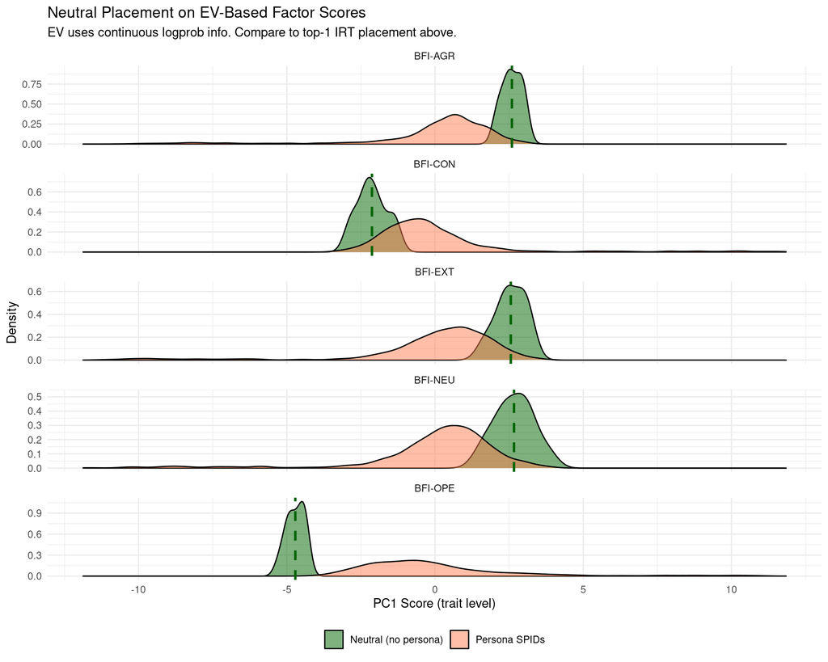

```r
ev_placement_df <- names(ev_results) %>%
  map_dfr(function(s) {
    r <- ev_results[[s]]
    if (is.null(r$fa_l3)) return(NULL)

    persona <- tibble(Scale = s, score = r$fa_l3$scores, type = "Persona SPIDs")

    neutral <- if (!is.null(r$neutral_scores) && length(r$neutral_scores) > 0) {
      tibble(Scale = s, score = r$neutral_scores, type = "Neutral (no persona)")
    }

    bind_rows(persona, neutral)
  })

if (nrow(ev_placement_df) > 0 &&
    any(ev_placement_df$type == "Neutral (no persona)")) {

  ev_neutral_summary <- ev_placement_df %>%
    group_by(Scale, type) %>%
    summarise(mean_score = mean(score), sd_score = sd(score), .groups = "drop")

  ev_neutral_summary %>%
    knitr::kable(digits = 3,
                 caption = "EV-based factor scores: Neutral vs Persona")

  # Percentile
  ev_pctl <- names(ev_results) %>%
    map_dfr(function(s) {
      r <- ev_results[[s]]
      if (is.null(r$fa_l3) || is.null(r$neutral_scores) ||
          length(r$neutral_scores) == 0) return(NULL)
      persona_scores <- r$fa_l3$scores
      neut_mean <- mean(r$neutral_scores)
      tibble(
        Scale = s,
        neutral_mean = neut_mean,
        percentile = mean(persona_scores <= neut_mean) * 100
      )
    })

  ev_pctl %>%
    knitr::kable(digits = 2,
                 caption = "Neutral as percentile of persona distribution (EV-based)")

  ev_placement_df %>%
    ggplot(aes(x = score, fill = type)) +
    geom_density(alpha = 0.5) +
    geom_vline(data = ev_neutral_summary %>% filter(type == "Neutral (no persona)"),
               aes(xintercept = mean_score), color = "darkgreen",
               linetype = "dashed", linewidth = 1) +
    facet_wrap(~Scale, scales = "free_y", ncol = 1) +
    scale_fill_manual(values = c("Persona SPIDs" = "coral",
                                  "Neutral (no persona)" = "darkgreen")) +
    labs(title = "Neutral Placement on EV-Based Factor Scores",
         subtitle = "EV uses continuous logprob info. Compare to top-1 IRT placement above.",
         x = "PC1 Score (trait level)", y = "Density", fill = NULL) +
    theme_minimal() +
    theme(legend.position = "bottom")
}
```

## 7. Placing Neutral (No-Persona) Responses on the Trait Scale (Top-1 IRT)

Using the IRT models fitted on persona data, we compute factor scores for the neutral (no-persona) SPIDs. This locates the model’s “resting state” on each Big Five dimension as defined by the persona-induced variation.

We use the **best-fitting top-1 model** (GRM or NRM per scale) and compute both:

- **Top-1 factor scores**: Using the argmax response
- **Soft-evidence factor scores**: Using the full logprob distribution (if soft model is viable)

```r
neutral_placement <- list()

for (scale_id in names(bfi_scales)) {
  items <- bfi_scales[[scale_id]]$items
  rev_items <- bfi_scales[[scale_id]]$reverse
  r3 <- results_l3[[scale_id]]

  # Use GRM top-1 as reference model (always works)
  ref_mod <- r3$grm_top1
  if (is.null(ref_mod)) next

  # Build neutral response data
  neut_data <- build_neutral_softmat(df_l3_neutral, items, all_items,
                                      ref_mod, rev_items)
  if (is.null(neut_data$dat) || nrow(neut_data$dat) == 0) next

  # Top-1 factor scores for neutral
  neut_fs_top1 <- tryCatch(
    fscores(ref_mod, response.pattern = neut_data$dat, method = "EAP"),
    error = function(e) NULL
  )

  # Factor scores for all persona SPIDs (for comparison)
  persona_fs <- tryCatch(
    fscores(ref_mod, method = "EAP"),
    error = function(e) NULL
  )

  # Soft-evidence factor scores for neutral (if soft model is viable)
  soft_mod <- r3$grm_soft
  neut_fs_soft <- NULL
  if (!is.null(soft_mod)) {
    neut_fs_soft <- tryCatch(
      fscores(soft_mod, response.pattern = neut_data$dat, method = "EAP"),
      error = function(e) NULL
    )
  }

  neutral_placement[[scale_id]] <- list(
    neut_fs_top1 = neut_fs_top1,
    neut_fs_soft = neut_fs_soft,
    persona_fs = persona_fs,
    neut_spids = neut_data$spids,
    neut_dat = neut_data$dat
  )
}
```

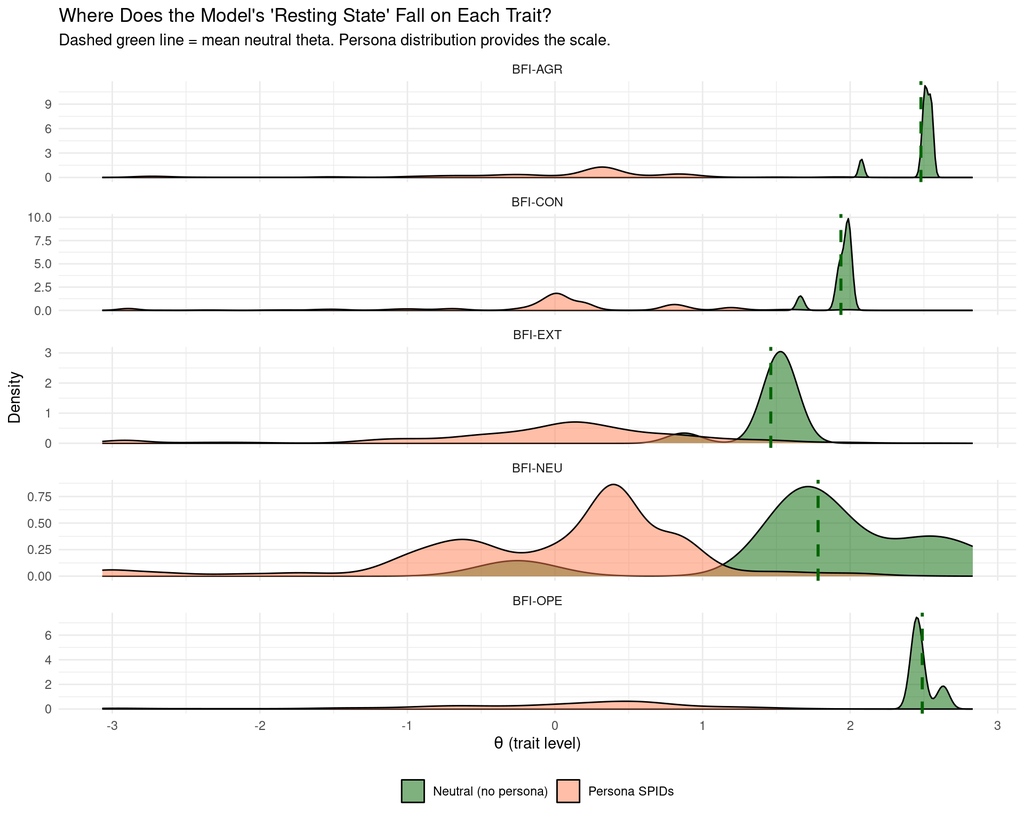

```r
placement_df <- names(neutral_placement) %>%
  map_dfr(function(s) {
    np <- neutral_placement[[s]]
    if (is.null(np$persona_fs) || is.null(np$neut_fs_top1)) return(NULL)

    persona_thetas <- tibble(
      Scale = s,
      theta = np$persona_fs[, "F1"],
      type = "Persona SPIDs"
    )

    neutral_thetas <- tibble(
      Scale = s,
      theta = np$neut_fs_top1[, "F1"],
      type = "Neutral (no persona)"
    )

    bind_rows(persona_thetas, neutral_thetas)
  })

if (nrow(placement_df) > 0) {
  # Summary statistics
  neutral_summary <- placement_df %>%
    group_by(Scale, type) %>%
    summarise(
      mean_theta = mean(theta),
      sd_theta = sd(theta),
      median_theta = median(theta),
      .groups = "drop"
    )

  neutral_summary %>%
    knitr::kable(digits = 3,
                 caption = "Factor score summary: Neutral vs Persona SPIDs")

  # Density plot
  placement_df %>%
    ggplot(aes(x = theta, fill = type)) +
    geom_density(alpha = 0.5) +
    geom_vline(data = neutral_summary %>% filter(type == "Neutral (no persona)"),
               aes(xintercept = mean_theta), color = "darkgreen",
               linetype = "dashed", linewidth = 1) +
    facet_wrap(~Scale, scales = "free_y", ncol = 1) +
    scale_fill_manual(values = c("Persona SPIDs" = "coral",
                                  "Neutral (no persona)" = "darkgreen")) +
    labs(title = "Where Does the Model's 'Resting State' Fall on Each Trait?",
         subtitle = "Dashed green line = mean neutral theta. Persona distribution provides the scale.",
         x = expression(theta ~ "(trait level)"), y = "Density", fill = NULL) +
    theme_minimal() +
    theme(legend.position = "bottom")
}
```

### Neutral theta as percentile of persona distribution

```r
if (nrow(placement_df) > 0) {
  percentile_df <- names(neutral_placement) %>%
    map_dfr(function(s) {
      np <- neutral_placement[[s]]
      if (is.null(np$persona_fs) || is.null(np$neut_fs_top1)) return(NULL)
      persona_thetas <- np$persona_fs[, "F1"]
      neut_mean <- mean(np$neut_fs_top1[, "F1"])
      tibble(
        Scale = s,
        neutral_mean_theta = neut_mean,
        percentile = mean(persona_thetas <= neut_mean) * 100,
        persona_mean = mean(persona_thetas),
        persona_sd = sd(persona_thetas)
      )
    })

  percentile_df %>%
    knitr::kable(digits = 2,
                 caption = "Neutral (resting state) as percentile of persona distribution")
}
```

Neutral (resting state) as percentile of persona distribution

| Scale | neutral_mean_theta | percentile | persona_mean | persona_sd |
| --- | --- | --- | --- | --- |
| BFI-EXT | 1.46 | 96.16 | 0 | 0.94 |
| BFI-AGR | 2.48 | 100.00 | 0 | 0.93 |
| BFI-CON | 1.94 | 98.98 | 0 | 0.92 |
| BFI-NEU | 1.78 | 98.42 | 0 | 0.92 |
| BFI-OPE | 2.49 | 100.00 | 0 | 0.96 |

## 8. Summary

### Key findings

```r
tribble(
  ~Question, ~Finding,
  "Does Llama-3.2 use more response categories?",
    sprintf("Observed categories: {%s}", paste(obs_cats_l3, collapse = ", ")),
  "More entropy in logprobs?",
    "See entropy comparison above",
  "Soft-evidence IRT viable?",
    ifelse(any(!soft_both$L3_degenerate),
           "PARTIAL — discrimination recovered for some scales (OPE), degenerate for others",
           "NO — still degenerate (a1 ≈ 0). Distributional shape is item-level, not person-level."),
  "EV-based factor analysis",
    "Captures continuous between-person variation from logprobs without soft-evidence assumptions",
  "Neutral resting state location",
    "See percentile tables above (both top-1 IRT and EV-based)"
) %>%
  knitr::kable(caption = "Summary of key questions")
```

[output not shown]

Summary of key questions

[output not shown]

```
## Session info:
```

```
##   mirt version: 1.46.2
```

```
##   R version: R version 4.5.2 (2025-10-31)
```